# Project 3

Tobechi Dimkpa

Feb 11 2025

# SAT Data Analysis

### a)

```r
sat_data <- read_xls("data/sat_data.xls") %>%
 janitor::clean_names()
```

### b)

Creating two new variables which calculate the total SAT score for 2004 and 2005 for each state.

```r
sat_data <- sat_data %>%
  mutate(total_sat_2005= verbal_sat_2005 + math_sat_2005_5,   total_sat_2004= verbal_sat_2004 + math_sat_2005_7)
```

### c)

Was there a relationship between verbal and math SAT scores in 2005?

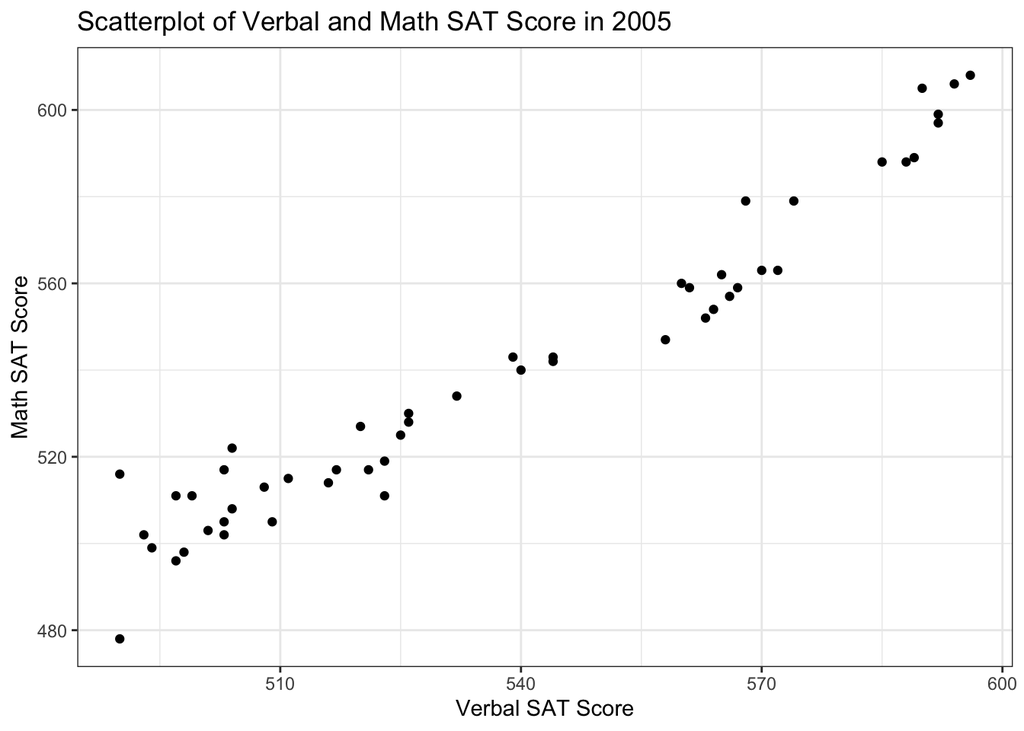

```r
ggplot (data = sat_data) +
  geom_point(aes(x = verbal_sat_2005, y=math_sat_2005_5 )) +
  labs(title = "Scatterplot of Verbal and Math SAT Score in 2005", x= "Verbal SAT Score", y="Math SAT Score" ) +
  theme_bw()
```

```r
#Yes there is a relationship. As verbal SAT scores increased, so did the nath scores.
```

### d)

Average total score by region in 2004 and 2005. Which region had the lowest performance in 2004? Which had the best performance in 2004? What about 2005?

```r
average_sat <- sat_data %>%
  group_by(region) %>%
  summarise(mean_2005 = mean(total_sat_2005), mean_2004 = mean(total_sat_2004))
kable(average_sat)
```

| region | mean_2005 | mean_2004 |
| --- | --- | --- |
| ENC | 1126.400 | 1117.600 |
| ESC | 1124.750 | 1115.500 |
| MA | 1010.667 | 1008.333 |
| MTN | 1084.750 | 1080.625 |
| NE | 1031.833 | 1025.500 |
| PAC | 1038.800 | 1033.400 |
| SA | 1006.111 | 1003.222 |
| WNC | 1181.143 | 1176.429 |
| WSC | 1092.500 | 1094.000 |

In 2004 and 2005, Region WNC had the best performance and SA had the worst.

### e)

Created a new participation variable with three groups:

- “low” for participation less than 50%
- “medium” for participation between 50% and 75%
- “high” for participation higher than 75%

```r
sat <- sat_data %>%
  mutate(participation = case_when(
    participation_pct < 50 ~ "low",
    participation_pct >= 50 & participation_pct < 75 ~ "medium",
    participation_pct >= 75 ~ "high"
      ))
```

### f)

Created a heatmap showing average performance in 2005 by region and the new participation variable.

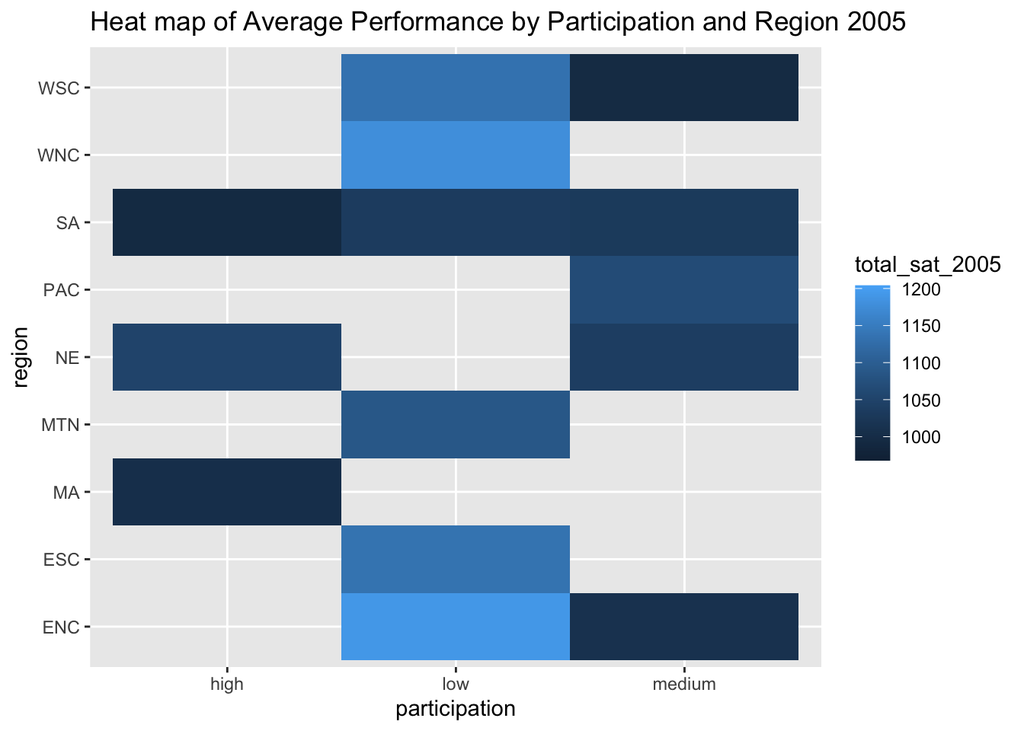

```r
ggplot(data = sat) +
  geom_tile(aes(x = participation, y= region, fill = total_sat_2005)) +
  labs(title = "Heat map of Average Performance by Participation and Region 2005")
```

### g)

Improved the visualization of your heatmap by doing the following:

1. Ensure that the plot has an appropriate title and that both axes and the legend are properly labeled.
2. Make sure the participation groups are presented in a logical order.
3. Use a `theme()` statement to remove the grey panel background.
4. Use a `theme()` statement to increase the axis text size to 14.

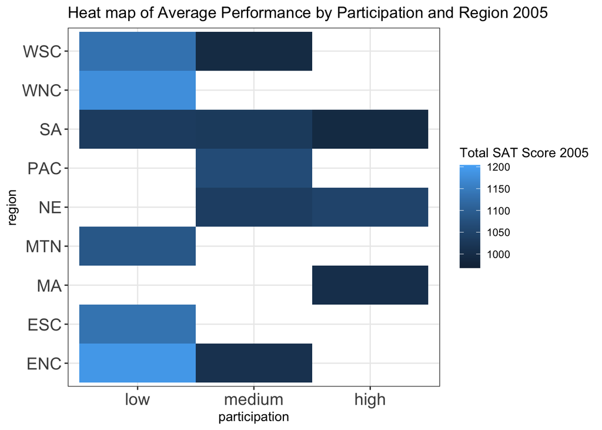

```r
sat %>%
  mutate(`participation` = factor(`participation`, levels = c("low", "medium", "high"))) %>%
ggplot() +
  geom_tile(aes(x = participation, y= region, fill = total_sat_2005)) +
  labs(title = "Heat map of Average Performance by Participation and Region 2005", fill = "Total SAT Score 2005") +
  theme_bw() +
  theme(axis.text = element_text(size = 14))
```

# Improving visualiztions: cancer data

It seems like it was very popular to create 3D bar graphs for studies of cancer genes in the mid 2000’s. Here is another visualization from a peer-reviewed publish paper:

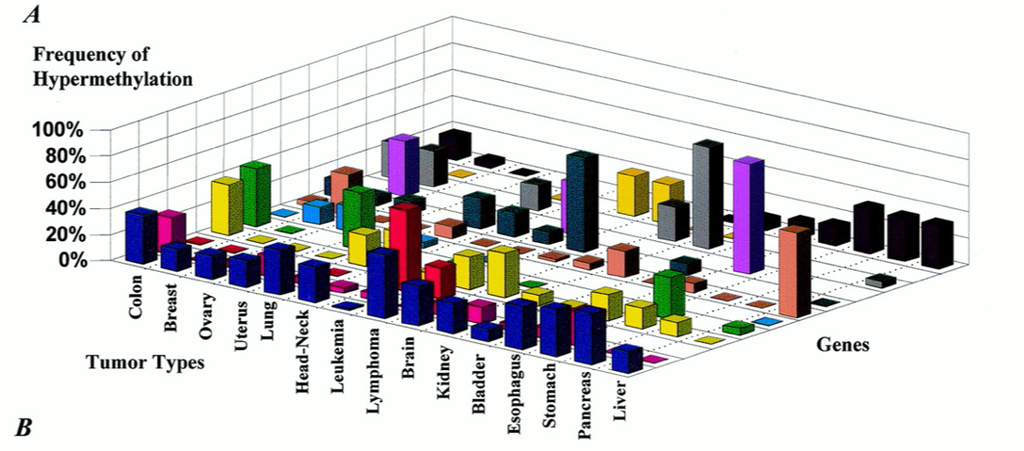

**Why was this so popular? No idea… but thankfully times have changed!**

### a)

Loaded the cancer gene data from the “cancer_genes.csv” file

```r
cancer_genes <- read_csv("data/cancer_genes.csv", skip=2)
```

### b)

create a heatmap visualization of hyper methylation for each tumor type + gene combination.

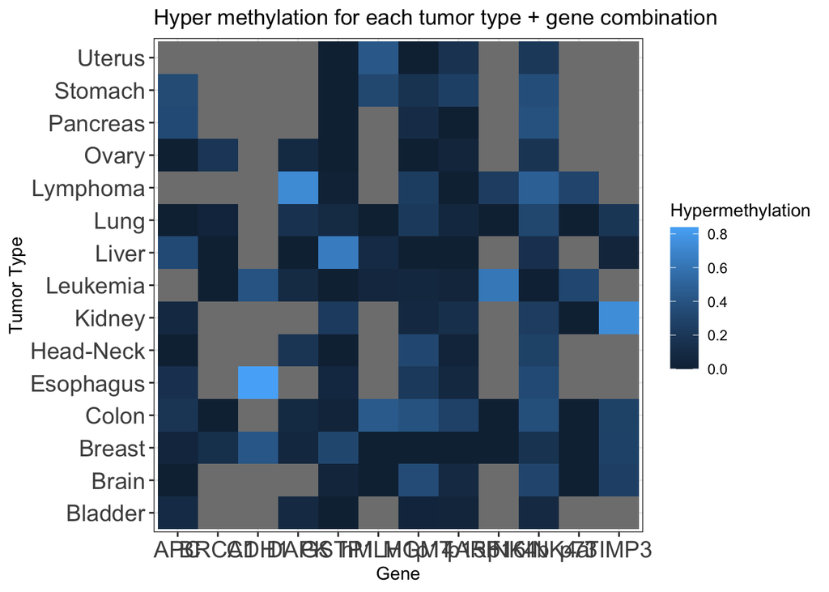

```r
ggplot(data = cancer_genes) +
  geom_tile(aes(x = gene, y= tumor_type, fill = hyper_methylation)) +
  labs(title = "Hyper methylation for each tumor type + gene combination", x = "Gene", y= "Tumor Type", fill = "Hypermethylation") +
  theme_bw() +
  theme(axis.text = element_text(size = 14))
```

### c)

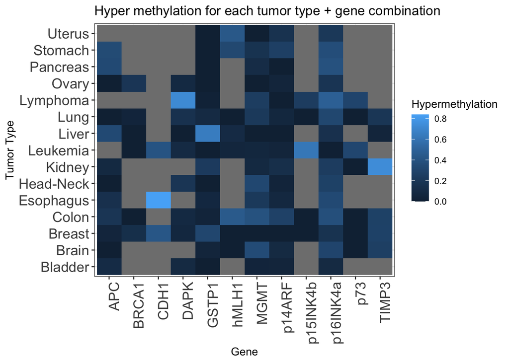

```r
ggplot(data = cancer_genes) +
  geom_tile(aes(x = gene, y= tumor_type, fill = hyper_methylation)) +
  labs(title = "Hyper methylation for each tumor type + gene combination", x = "Gene", y= "Tumor Type", fill = "Hypermethylation") +
  theme_bw() +
  theme(axis.text = element_text(size = 14)) +
  theme(axis.text.x = element_text(angle=90, hjust=1))
```

`theme(axis.text.x = element_text(angle = 90))` rotated the x axis label to reduce crowding

### d)

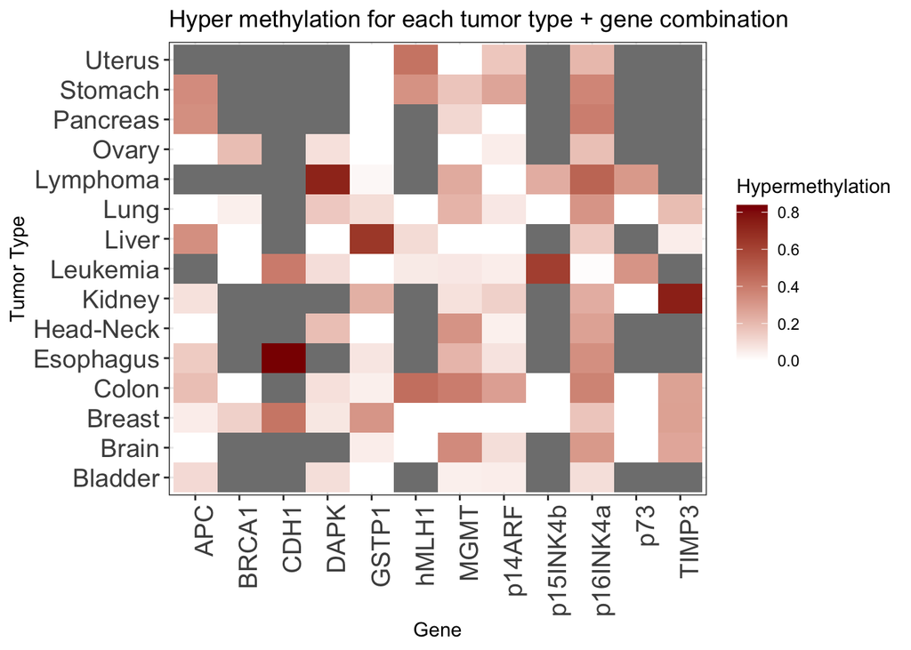

```r
ggplot(data = cancer_genes) +
  geom_tile(aes(x = gene, y= tumor_type, fill = hyper_methylation)) +
  labs(title = "Hyper methylation for each tumor type + gene combination", x = "Gene", y= "Tumor Type", fill = "Hypermethylation") +
  theme_bw() +
  theme(axis.text = element_text(size = 14)) +
  theme(axis.text.x = element_text(angle=90, hjust=1)) +
  scale_fill_gradient(high = "darkred", low = "white")
```

```r
#`scale_fill_gradient(high = "white", low = "darkred")` changed the color gradient for the fill aesthetic
#It doesn't make sense because the darkest color should be the highest number so I flipped the colors
```

# Question 3

Dataset for treatment compliance: dataset of treatment compliance for a 10-week study on physical activity and cognitive functioning. This data set can be found in the `activity_compliance.csv` file.

### a)

Load the compliance data

```r
activity_compliance <- read_csv("data/activity_compliance.csv")
```

### b)

The data set contains missing compliance observations. For the purpose of this exercise, we will treat missing data as non-compliant. Change all NA compliance values to 0 and use this updated dataset for the following problems.

```r
compliance <- activity_compliance %>%
  mutate(compliant = replace_na(compliant, 0))

print(compliance)
```

```
## # A tibble: 600 × 3
##     week compliant    id
##    <dbl>     <dbl> <dbl>
##  1     1         1     1
##  2     1         1     2
##  3     1         1     3
##  4     1         1     4
##  5     1         1     5
##  6     1         1     6
##  7     1         1     7
##  8     1         1     8
##  9     1         1     9
## 10     1         1    10
## # ℹ 590 more rows
```

### c)

Created a summary data frame of the proportion of compliant individuals per week and its 95% confidence interval.

```r
compliance_summary <- compliance %>%
  group_by(week) %>%
  summarize(total_individuals = n(),
    compliant_count = sum(compliant == 1, na.rm = TRUE),  # Count compliant individuals
    proportion_compliant = compliant_count / total_individuals  # Calculate proportion
  ) %>%
  # Calculate 95% confidence interval
  mutate(
    ci_lower = proportion_compliant - 1.96 * sqrt((proportion_compliant * (1 - proportion_compliant)) / total_individuals),
    ci_upper = proportion_compliant + 1.96 * sqrt((proportion_compliant * (1 - proportion_compliant)) / total_individuals)
  )
kable(compliance_summary)
```

| week | total_individuals | compliant_count | proportion_compliant | ci_lower | ci_upper |
| --- | --- | --- | --- | --- | --- |
| 1 | 60 | 48 | 0.8000000 | 0.6987860 | 0.9012140 |
| 2 | 60 | 45 | 0.7500000 | 0.6404327 | 0.8595673 |
| 3 | 60 | 39 | 0.6500000 | 0.5293100 | 0.7706900 |
| 4 | 60 | 45 | 0.7500000 | 0.6404327 | 0.8595673 |
| 5 | 60 | 34 | 0.5666667 | 0.4412789 | 0.6920545 |
| 6 | 60 | 31 | 0.5166667 | 0.3902195 | 0.6431138 |
| 7 | 60 | 28 | 0.4666667 | 0.3404307 | 0.5929027 |
| 8 | 60 | 40 | 0.6666667 | 0.5473849 | 0.7859485 |
| 9 | 60 | 37 | 0.6166667 | 0.4936415 | 0.7396918 |
| 10 | 60 | 31 | 0.5166667 | 0.3902195 | 0.6431138 |

### d)

Created a graph that shows the proportion of compliant individuals and it’s 95% confidence interval per week. The ymax and ymin aesthetics should be mapped to the upper and lower bounds of the calculated 95% Confidence interval.

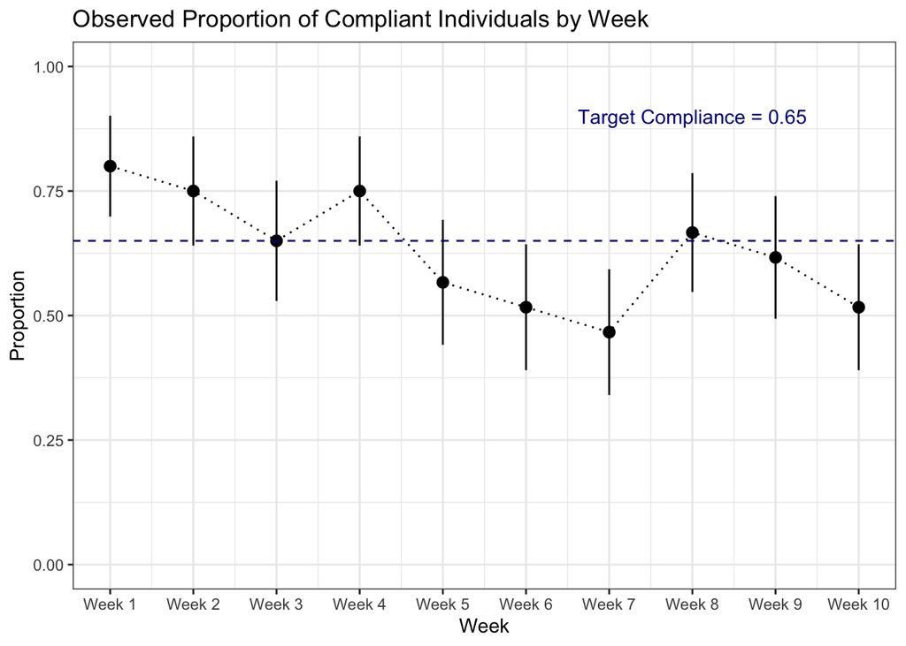

```r
ggplot(data = compliance_summary) +   # Fill in the summary data frame you create
  geom_pointrange(aes(x = week , y = proportion_compliant, ymax =ci_upper , ymin = ci_lower)) +  # Fill in the x, y, ymax, and ymin aesthetics (ymax and ymin are for your CI's)
  geom_line(aes(x = week , y = proportion_compliant), linetype = "dotted") +     # Fill in the x and y aesthetics (the same as above)
  geom_hline(aes(yintercept = 0.65), color = "darkblue", linetype = "dashed") +
  theme_bw() +
  labs(title = "Observed Proportion of Compliant Individuals by Week", x = "Week", y = "Proportion") +
  scale_x_continuous(breaks = 1:10, labels = paste("Week", 1:10)) +
  scale_y_continuous(limits = 0:1) +
  annotate(geom = "text", x = 8, y = 0.9, label = "Target Compliance = 0.65", color = "darkblue")
```

```r
#Geom_pointrange plots points of the proportion of compliant individuals per week
#Geom_line plots a dotted line connecting the points to visualize changes in compliance over time.
#Geom_hline creates a horizontal dashed line that signifies target compliance of 0.65 to easily compare deviations from the target
#theme_bw applies the black and white theme with minimal grid lines and a white background
#labs gives the graph a title and labels the x and y axis
#scale_x_continuous gives the scale for the x axis and adds the labels (Week 1-10)
# scale_y_continuous sets the y-axis limits between 0 and 1
#annotate adds text annotation to the plot at coordinates (x = 8, y = 0.9) with the label "Target Compliance = 0.65".
```

# Random Sampling from a Normal Distribution

### a)

Created a dataset made up of 100,000 random samples from a standard normal distribution (mean = 0, standard deviation = 1).

```r
normal_sample <- rnorm(n= 100000, mean = 0, sd = 1)
sampled_df <-tibble(rand = normal_sample)
```

### b)

Visualizing the distribution

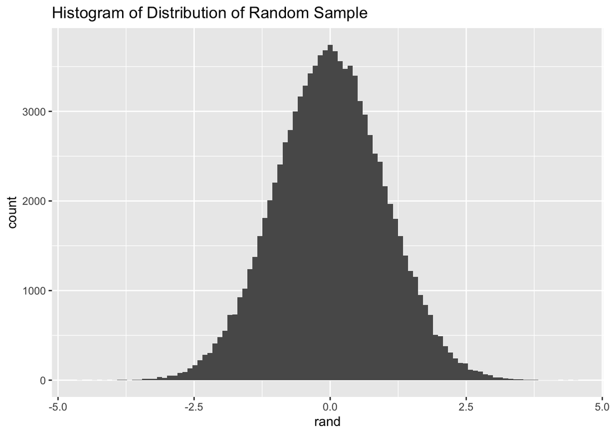

```r
ggplot(data = sampled_df) +
  geom_histogram(aes(x= rand), bins=100) +
  labs(title = "Histogram of Distribution of Random Sample")
```

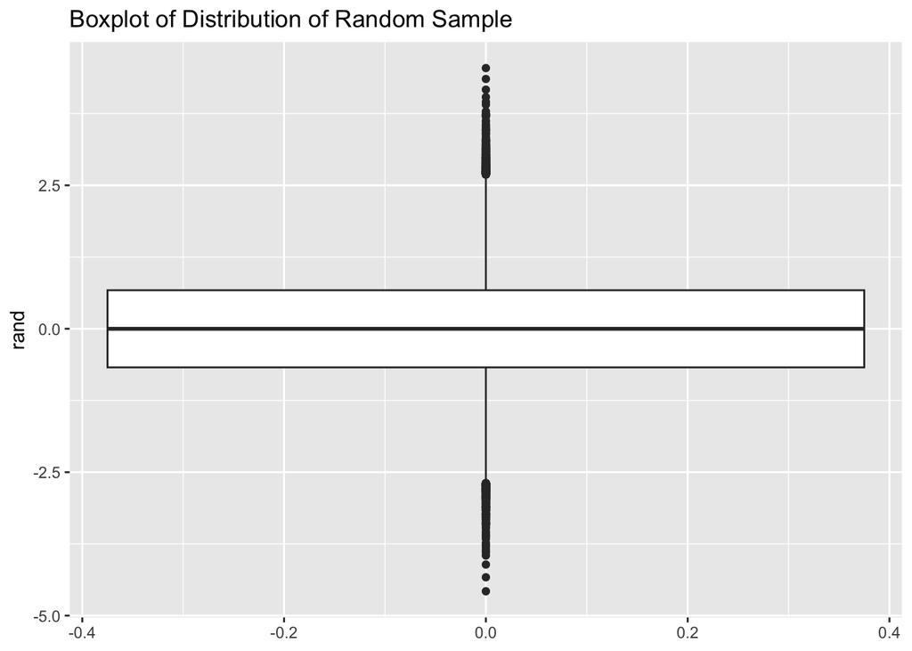

```r
ggplot(data = sampled_df) +
  geom_boxplot(aes(y= rand)) +
  labs(title = "Boxplot of Distribution of Random Sample")
```

```r
#It's easier to interpret the histogram because you can see most of the values are within the same range
```

### c)

Improving visualization

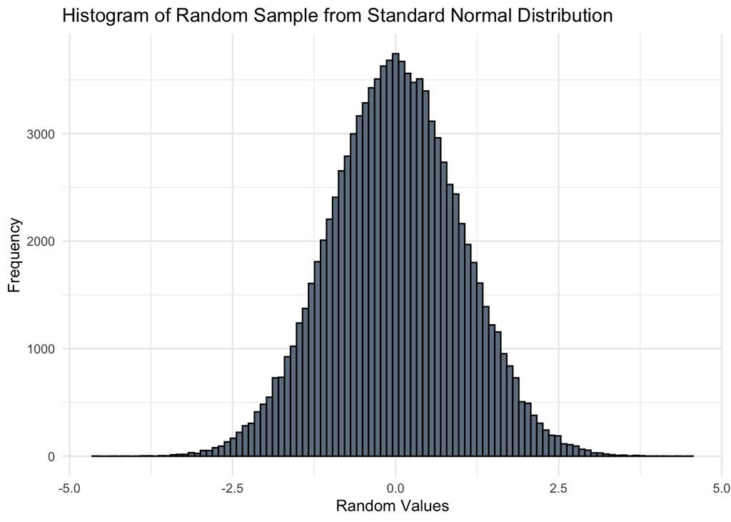

```r
ggplot(data = sampled_df) +
  geom_histogram(aes(x= rand), bins = 100, color="black", fill = "slategray") +
  labs(title = "Histogram of Random Sample from Standard Normal Distribution",x = "Random Values",y = "Frequency")+
  theme_minimal()
```

# Biometrics Data Analysis

### a)

Load the biometrics data in from `biometrics.xls`.

```r
biometrics_raw <- read_xls("data/biometrics.xls", sheet = 2)
```

### b)

Keep only id, height, weight, gender, and girth-related variables.

```r
biometrics <- biometrics_raw %>%
  select(id, height, weight, gender, contains("girth"))
```

### c)

Calculate BMI. Heights were recorded in cm, so converted to meters. Rounded BMI to 1 decimal place.

```r
biometrics <- biometrics %>%
  mutate(bmi = round(weight/ ((height*0.01)^2), 1))
```

### d)

New variable created: navel_thigh = navel_girth + thigh_girth. Distribution plotted using histogram.

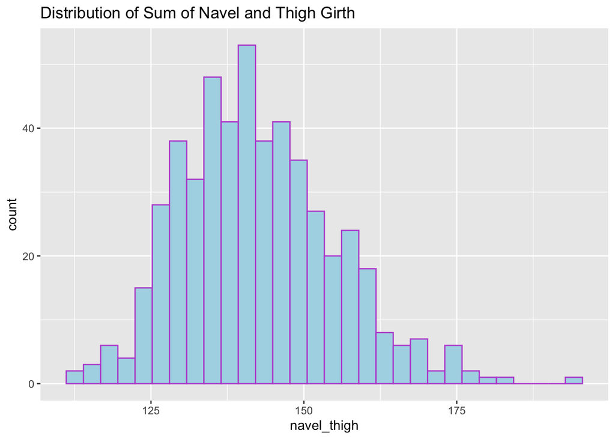

```r
biometrics <- biometrics %>%
  mutate(navel_thigh = navel_girth + thigh_girth)

ggplot(data = biometrics)+
  geom_histogram(aes(x= navel_thigh), color= "mediumorchid", fill= "lightblue") +
  labs(title = "Distribution of Sum of Navel and Thigh Girth")
```

### e)

Explore whether there is a relationship between continuous BMI and the new navel + thigh girth variable.

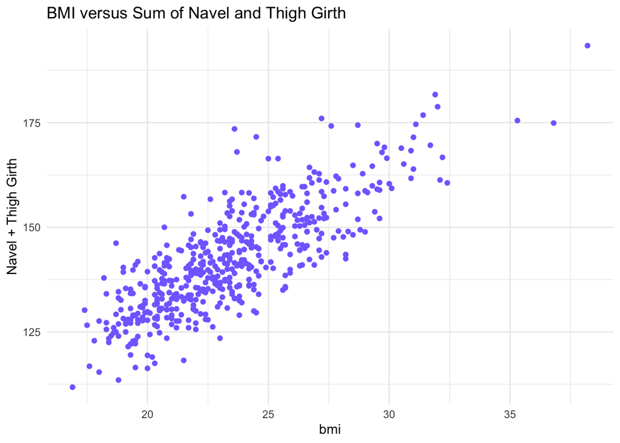

```r
ggplot(data = biometrics)+
  geom_point(aes(x=bmi, y=navel_thigh), color = "slateblue1") +
  labs(title = "BMI versus Sum of Navel and Thigh Girth", y = "Navel + Thigh Girth")+
  theme_minimal() +
  theme()
```

```r
#Yes, as BMI increases the navel +thigh girth variable increases
```

### f)

Create a categorical variable that reflects these BMI categories:

- Underweight: BMI less than 18.5
- Normal: BMI greater than or equal to 18.5 but less than 25
- Overweight: BMI greater than or equal to 25 but less than 30
- Obese: BMI greater than or equal to 30.

```r
biometrics <- biometrics %>%
  mutate(bmi_4cat = case_when(
    bmi < 18.5 ~ "Underweight",
    bmi >= 18.5 & bmi < 25 ~ "Normal",
    bmi >= 25 & bmi < 30 ~ "Overweight",
    bmi >= 30 ~ "Obese"))
```

### g)

Report the proportion of individuals who are in each BMI category within each gender.

```r
gender_proportion_bmi <- biometrics %>%
  group_by(gender, bmi_4cat) %>%
  summarize(n = n()) %>%
  mutate(gender_proportion = n/ sum(n))

  kable(gender_proportion_bmi)
```

| gender | bmi_4cat | n | gender_proportion |
| --- | --- | --- | --- |
| Female | Normal | 203 | 0.7807692 |
| Female | Obese | 9 | 0.0346154 |
| Female | Overweight | 36 | 0.1384615 |
| Female | Underweight | 12 | 0.0461538 |
| Male | Normal | 141 | 0.5708502 |
| Male | Obese | 10 | 0.0404858 |
| Male | Overweight | 95 | 0.3846154 |
| Male | Underweight | 1 | 0.0040486 |

### h)

Create a faceted scatterplot of BMI by navel + thigh girth by both BMI category and gender.

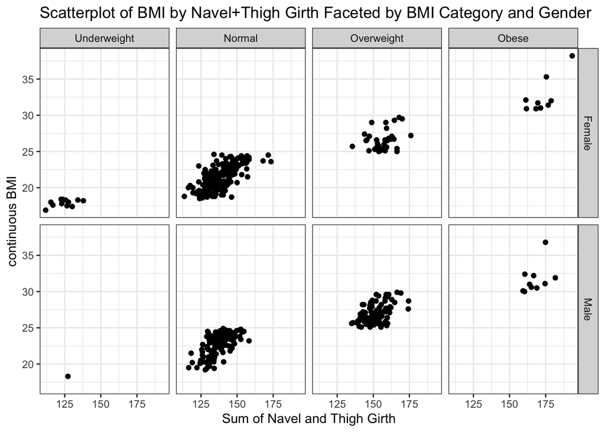

```r
biometrics %>%
  mutate(`bmi_4cat` = factor(`bmi_4cat`, levels = c("Underweight", "Normal", "Overweight", "Obese"))) %>%
ggplot()+
  geom_point(aes(x=navel_thigh, y=bmi))+
  facet_grid(gender ~ bmi_4cat)+
  labs(title = "Scatterplot of BMI by Navel+Thigh Girth Faceted by BMI Category and Gender", x= "Sum of Navel and Thigh Girth", y= "continuous BMI")+
  theme_bw()
```